# Risk Factor Analysis

## Outcome Variable

**Outcome Variable:** y_rate_wtkg

## Predictor Variables

**Intervention Variable:** nhh

**Adjustment Set:**

unadjusted

## Stratifying Variables

The analysis was stratified on these variable(s):

- agecat
- studyid
- country

## Data Summary

| agecat | studyid | country | nhh | n_cell | n |
| --- | --- | --- | --- | --- | --- |
| 0-3 months | IRC | INDIA | 3 or less | 57 | 394 |
| 0-3 months | IRC | INDIA | 4-5 | 151 | 394 |
| 0-3 months | IRC | INDIA | 6-7 | 101 | 394 |
| 0-3 months | IRC | INDIA | 8+ | 85 | 394 |
| 0-3 months | NIH-Birth | BANGLADESH | 3 or less | 101 | 565 |
| 0-3 months | NIH-Birth | BANGLADESH | 4-5 | 238 | 565 |
| 0-3 months | NIH-Birth | BANGLADESH | 6-7 | 132 | 565 |
| 0-3 months | NIH-Birth | BANGLADESH | 8+ | 94 | 565 |
| 0-3 months | NIH-Crypto | BANGLADESH | 3 or less | 110 | 725 |
| 0-3 months | NIH-Crypto | BANGLADESH | 4-5 | 324 | 725 |
| 0-3 months | NIH-Crypto | BANGLADESH | 6-7 | 171 | 725 |
| 0-3 months | NIH-Crypto | BANGLADESH | 8+ | 120 | 725 |
| 0-3 months | PROVIDE | BANGLADESH | 3 or less | 123 | 640 |
| 0-3 months | PROVIDE | BANGLADESH | 4-5 | 296 | 640 |
| 0-3 months | PROVIDE | BANGLADESH | 6-7 | 136 | 640 |
| 0-3 months | PROVIDE | BANGLADESH | 8+ | 85 | 640 |
| 3-6 months | IRC | INDIA | 3 or less | 57 | 399 |
| 3-6 months | IRC | INDIA | 4-5 | 153 | 399 |
| 3-6 months | IRC | INDIA | 6-7 | 104 | 399 |
| 3-6 months | IRC | INDIA | 8+ | 85 | 399 |
| 3-6 months | NIH-Birth | BANGLADESH | 3 or less | 89 | 522 |
| 3-6 months | NIH-Birth | BANGLADESH | 4-5 | 223 | 522 |
| 3-6 months | NIH-Birth | BANGLADESH | 6-7 | 125 | 522 |
| 3-6 months | NIH-Birth | BANGLADESH | 8+ | 85 | 522 |
| 3-6 months | NIH-Crypto | BANGLADESH | 3 or less | 103 | 702 |
| 3-6 months | NIH-Crypto | BANGLADESH | 4-5 | 317 | 702 |
| 3-6 months | NIH-Crypto | BANGLADESH | 6-7 | 167 | 702 |
| 3-6 months | NIH-Crypto | BANGLADESH | 8+ | 115 | 702 |
| 3-6 months | PROVIDE | BANGLADESH | 3 or less | 105 | 601 |
| 3-6 months | PROVIDE | BANGLADESH | 4-5 | 287 | 601 |

[output cut: 138 more lines]

The following strata were considered:

- agecat: 0-3 months, studyid: IRC, country: INDIA
- agecat: 0-3 months, studyid: NIH-Birth, country: BANGLADESH
- agecat: 0-3 months, studyid: NIH-Crypto, country: BANGLADESH
- agecat: 0-3 months, studyid: PROVIDE, country: BANGLADESH
- agecat: 12-15 months, studyid: IRC, country: INDIA
- agecat: 12-15 months, studyid: LCNI-5, country: MALAWI
- agecat: 12-15 months, studyid: NIH-Birth, country: BANGLADESH
- agecat: 12-15 months, studyid: NIH-Crypto, country: BANGLADESH
- agecat: 12-15 months, studyid: PROVIDE, country: BANGLADESH
- agecat: 12-15 months, studyid: SAS-FoodSuppl, country: INDIA
- agecat: 15-18 months, studyid: IRC, country: INDIA
- agecat: 15-18 months, studyid: LCNI-5, country: MALAWI
- agecat: 15-18 months, studyid: NIH-Birth, country: BANGLADESH
- agecat: 15-18 months, studyid: NIH-Crypto, country: BANGLADESH
- agecat: 15-18 months, studyid: PROVIDE, country: BANGLADESH
- agecat: 15-18 months, studyid: SAS-FoodSuppl, country: INDIA
- agecat: 18-21 months, studyid: IRC, country: INDIA
- agecat: 18-21 months, studyid: LCNI-5, country: MALAWI
- agecat: 18-21 months, studyid: NIH-Birth, country: BANGLADESH
- agecat: 18-21 months, studyid: NIH-Crypto, country: BANGLADESH
- agecat: 18-21 months, studyid: PROVIDE, country: BANGLADESH
- agecat: 21-24 months, studyid: IRC, country: INDIA
- agecat: 21-24 months, studyid: LCNI-5, country: MALAWI
- agecat: 21-24 months, studyid: NIH-Birth, country: BANGLADESH
- agecat: 21-24 months, studyid: NIH-Crypto, country: BANGLADESH
- agecat: 21-24 months, studyid: PROVIDE, country: BANGLADESH
- agecat: 3-6 months, studyid: IRC, country: INDIA
- agecat: 3-6 months, studyid: NIH-Birth, country: BANGLADESH
- agecat: 3-6 months, studyid: NIH-Crypto, country: BANGLADESH
- agecat: 3-6 months, studyid: PROVIDE, country: BANGLADESH
- agecat: 6-9 months, studyid: IRC, country: INDIA
- agecat: 6-9 months, studyid: LCNI-5, country: MALAWI
- agecat: 6-9 months, studyid: NIH-Birth, country: BANGLADESH
- agecat: 6-9 months, studyid: NIH-Crypto, country: BANGLADESH
- agecat: 6-9 months, studyid: PROVIDE, country: BANGLADESH
- agecat: 6-9 months, studyid: SAS-FoodSuppl, country: INDIA
- agecat: 9-12 months, studyid: IRC, country: INDIA
- agecat: 9-12 months, studyid: LCNI-5, country: MALAWI
- agecat: 9-12 months, studyid: NIH-Birth, country: BANGLADESH
- agecat: 9-12 months, studyid: NIH-Crypto, country: BANGLADESH
- agecat: 9-12 months, studyid: PROVIDE, country: BANGLADESH
- agecat: 9-12 months, studyid: SAS-FoodSuppl, country: INDIA

## Methods Detail

We’re interested in the causal parameters $E[Y_a]$ for all values of $a \in \mathcal{A}$. These parameters represent the mean outcome if, possibly contrary to fact, we intervened to set all units to have $A=a$. Under the randomization and positivity assumptions, these are identified by the statistical parameters $\psi_a=E_W[E_{Y|A,W}(Y|A=a,W)]$. In addition, we’re interested in the mean of $Y$, $E[Y]$ under no intervention (the observed mean). We will estimate these parameters by using SuperLearner to fit the relevant likelihood factors – $E_{Y|A,W}(Y|A=a,W)$ and $p(A=a|W)$, and then updating our likelihood fit using a joint TMLE.

For unadjusted analyses ($W=\{\}$), initial likelihoods were estimated using Lrnr_glm to estimate the simple $E(Y|A)$ and Lrnr_mean to estimate $p(A)$. For adjusted analyses, a small library containing Lrnr_glmnet, Lrnr_xgboost, and Lrnr_mean was used.

Having estimated these parameters, we will then use the delta method to estimate relative risks and attributable risks relative to a prespecified baseline level of $A$.

# Results Detail

## Results Plots

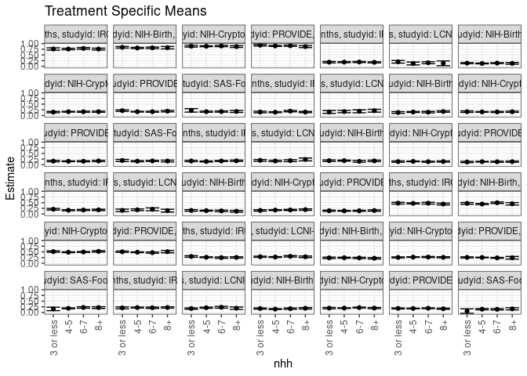

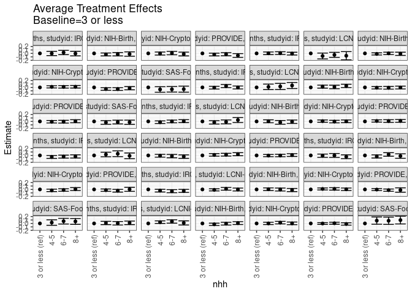

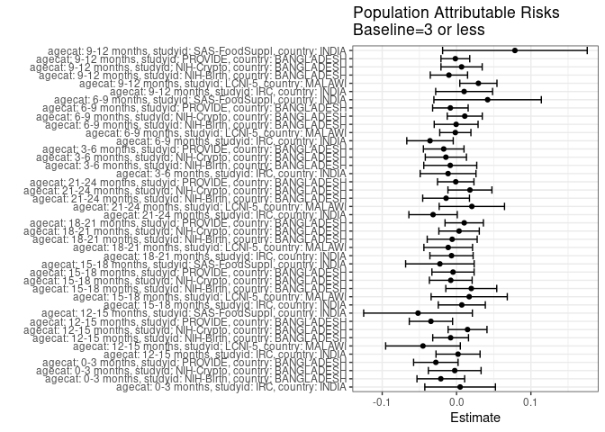

## Results Table

### Parameter: TSM

| agecat | studyid | country | intervention_level | baseline_level | estimate | ci_lower | ci_upper |
| --- | --- | --- | --- | --- | --- | --- | --- |
| 0-3 months | IRC | INDIA | 3 or less | NA | 0.7631826 | 0.7117816 | 0.8145837 |
| 0-3 months | IRC | INDIA | 4-5 | NA | 0.7611299 | 0.7282762 | 0.7939836 |
| 0-3 months | IRC | INDIA | 6-7 | NA | 0.7888425 | 0.7530664 | 0.8246186 |
| 0-3 months | IRC | INDIA | 8+ | NA | 0.7586255 | 0.7175390 | 0.7997119 |
| 0-3 months | NIH-Birth | BANGLADESH | 3 or less | NA | 0.8375192 | 0.8034597 | 0.8715788 |
| 0-3 months | NIH-Birth | BANGLADESH | 4-5 | NA | 0.8075540 | 0.7833285 | 0.8317796 |
| 0-3 months | NIH-Birth | BANGLADESH | 6-7 | NA | 0.8138995 | 0.7797834 | 0.8480155 |
| 0-3 months | NIH-Birth | BANGLADESH | 8+ | NA | 0.8193160 | 0.7664741 | 0.8721579 |
| 0-3 months | NIH-Crypto | BANGLADESH | 3 or less | NA | 0.8869765 | 0.8482346 | 0.9257183 |
| 0-3 months | NIH-Crypto | BANGLADESH | 4-5 | NA | 0.8831019 | 0.8623693 | 0.9038345 |
| 0-3 months | NIH-Crypto | BANGLADESH | 6-7 | NA | 0.8961977 | 0.8664820 | 0.9259134 |
| 0-3 months | NIH-Crypto | BANGLADESH | 8+ | NA | 0.8694683 | 0.8304417 | 0.9084949 |
| 0-3 months | PROVIDE | BANGLADESH | 3 or less | NA | 0.9295042 | 0.8963392 | 0.9626691 |
| 0-3 months | PROVIDE | BANGLADESH | 4-5 | NA | 0.8972529 | 0.8753416 | 0.9191643 |
| 0-3 months | PROVIDE | BANGLADESH | 6-7 | NA | 0.9065631 | 0.8765606 | 0.9365656 |
| 0-3 months | PROVIDE | BANGLADESH | 8+ | NA | 0.8687733 | 0.8262358 | 0.9113108 |
| 3-6 months | IRC | INDIA | 3 or less | NA | 0.4774581 | 0.4382115 | 0.5167046 |
| 3-6 months | IRC | INDIA | 4-5 | NA | 0.4694165 | 0.4440237 | 0.4948092 |
| 3-6 months | IRC | INDIA | 6-7 | NA | 0.4768242 | 0.4363056 | 0.5173428 |
| 3-6 months | IRC | INDIA | 8+ | NA | 0.4392595 | 0.4003139 | 0.4782052 |
| 3-6 months | NIH-Birth | BANGLADESH | 3 or less | NA | 0.4678593 | 0.4294191 | 0.5062996 |
| 3-6 months | NIH-Birth | BANGLADESH | 4-5 | NA | 0.4391549 | 0.4147124 | 0.4635974 |
| 3-6 months | NIH-Birth | BANGLADESH | 6-7 | NA | 0.4958946 | 0.4622978 | 0.5294914 |
| 3-6 months | NIH-Birth | BANGLADESH | 8+ | NA | 0.4499721 | 0.3969863 | 0.5029580 |
| 3-6 months | NIH-Crypto | BANGLADESH | 3 or less | NA | 0.5124196 | 0.4822361 | 0.5426032 |
| 3-6 months | NIH-Crypto | BANGLADESH | 4-5 | NA | 0.4856831 | 0.4691487 | 0.5022174 |
| 3-6 months | NIH-Crypto | BANGLADESH | 6-7 | NA | 0.4959663 | 0.4761681 | 0.5157645 |
| 3-6 months | NIH-Crypto | BANGLADESH | 8+ | NA | 0.5223222 | 0.4925310 | 0.5521135 |
| 3-6 months | PROVIDE | BANGLADESH | 3 or less | NA | 0.5063399 | 0.4766085 | 0.5360713 |
| 3-6 months | PROVIDE | BANGLADESH | 4-5 | NA | 0.4859354 | 0.4687893 | 0.5030815 |

[output cut: 138 more lines]

### Parameter: E(Y)

| agecat | studyid | country | intervention_level | baseline_level | estimate | ci_lower | ci_upper |
| --- | --- | --- | --- | --- | --- | --- | --- |
| 0-3 months | IRC | INDIA | NA | NA | 0.7679906 | 0.7485485 | 0.7874326 |
| 0-3 months | NIH-Birth | BANGLADESH | NA | NA | 0.8163500 | 0.7995330 | 0.8331670 |
| 0-3 months | NIH-Crypto | BANGLADESH | NA | NA | 0.8845220 | 0.8699746 | 0.8990694 |
| 0-3 months | PROVIDE | BANGLADESH | NA | NA | 0.9016472 | 0.8868914 | 0.9164029 |
| 3-6 months | IRC | INDIA | NA | NA | 0.4660717 | 0.4485044 | 0.4836390 |
| 3-6 months | NIH-Birth | BANGLADESH | NA | NA | 0.4593975 | 0.4422221 | 0.4765729 |
| 3-6 months | NIH-Crypto | BANGLADESH | NA | NA | 0.4980544 | 0.4869892 | 0.5091196 |
| 3-6 months | PROVIDE | BANGLADESH | NA | NA | 0.4890611 | 0.4760060 | 0.5021163 |
| 6-9 months | IRC | INDIA | NA | NA | 0.2626310 | 0.2487635 | 0.2764985 |
| 6-9 months | LCNI-5 | MALAWI | NA | NA | 0.2849079 | 0.2723110 | 0.2975048 |
| 6-9 months | NIH-Birth | BANGLADESH | NA | NA | 0.2362596 | 0.2225288 | 0.2499904 |
| 6-9 months | NIH-Crypto | BANGLADESH | NA | NA | 0.2675097 | 0.2569518 | 0.2780676 |
| 6-9 months | PROVIDE | BANGLADESH | NA | NA | 0.2491653 | 0.2371134 | 0.2612172 |
| 6-9 months | SAS-FoodSuppl | INDIA | NA | NA | 0.1982186 | 0.1818458 | 0.2145914 |
| 9-12 months | IRC | INDIA | NA | NA | 0.2132244 | 0.1989917 | 0.2274571 |
| 9-12 months | LCNI-5 | MALAWI | NA | NA | 0.2022567 | 0.1863082 | 0.2182053 |
| 9-12 months | NIH-Birth | BANGLADESH | NA | NA | 0.1636213 | 0.1504841 | 0.1767585 |
| 9-12 months | NIH-Crypto | BANGLADESH | NA | NA | 0.1978449 | 0.1874487 | 0.2082411 |
| 9-12 months | PROVIDE | BANGLADESH | NA | NA | 0.1775316 | 0.1681968 | 0.1868664 |
| 9-12 months | SAS-FoodSuppl | INDIA | NA | NA | 0.1410472 | 0.1219662 | 0.1601282 |
| 12-15 months | IRC | INDIA | NA | NA | 0.1821426 | 0.1693469 | 0.1949383 |
| 12-15 months | LCNI-5 | MALAWI | NA | NA | 0.1518822 | 0.1181702 | 0.1855942 |
| 12-15 months | NIH-Birth | BANGLADESH | NA | NA | 0.1305063 | 0.1184818 | 0.1425307 |
| 12-15 months | NIH-Crypto | BANGLADESH | NA | NA | 0.1640603 | 0.1535198 | 0.1746008 |
| 12-15 months | PROVIDE | BANGLADESH | NA | NA | 0.1800324 | 0.1683272 | 0.1917375 |
| 12-15 months | SAS-FoodSuppl | INDIA | NA | NA | 0.1752090 | 0.1590517 | 0.1913663 |
| 15-18 months | IRC | INDIA | NA | NA | 0.1604586 | 0.1468913 | 0.1740260 |
| 15-18 months | LCNI-5 | MALAWI | NA | NA | 0.1738706 | 0.1423337 | 0.2054074 |
| 15-18 months | NIH-Birth | BANGLADESH | NA | NA | 0.1529843 | 0.1384423 | 0.1675263 |
| 15-18 months | NIH-Crypto | BANGLADESH | NA | NA | 0.1611973 | 0.1506617 | 0.1717329 |
| 15-18 months | PROVIDE | BANGLADESH | NA | NA | 0.1563514 | 0.1445823 | 0.1681205 |
| 15-18 months | SAS-FoodSuppl | INDIA | NA | NA | 0.1648845 | 0.1491151 | 0.1806540 |
| 18-21 months | IRC | INDIA | NA | NA | 0.1589791 | 0.1455977 | 0.1723606 |
| 18-21 months | LCNI-5 | MALAWI | NA | NA | 0.1818489 | 0.1616805 | 0.2020172 |
| 18-21 months | NIH-Birth | BANGLADESH | NA | NA | 0.1724392 | 0.1563209 | 0.1885575 |
| 18-21 months | NIH-Crypto | BANGLADESH | NA | NA | 0.1426609 | 0.1319333 | 0.1533885 |
| 18-21 months | PROVIDE | BANGLADESH | NA | NA | 0.1324882 | 0.1210438 | 0.1439326 |
| 21-24 months | IRC | INDIA | NA | NA | 0.1777340 | 0.1639174 | 0.1915507 |
| 21-24 months | LCNI-5 | MALAWI | NA | NA | 0.1789517 | 0.1520986 | 0.2058049 |
| 21-24 months | NIH-Birth | BANGLADESH | NA | NA | 0.1419730 | 0.1267767 | 0.1571693 |
| 21-24 months | NIH-Crypto | BANGLADESH | NA | NA | 0.1750500 | 0.1624914 | 0.1876087 |
| 21-24 months | PROVIDE | BANGLADESH | NA | NA | 0.1419705 | 0.1305335 | 0.1534075 |

### Parameter: ATE

| agecat | studyid | country | intervention_level | baseline_level | estimate | ci_lower | ci_upper |
| --- | --- | --- | --- | --- | --- | --- | --- |
| 0-3 months | IRC | INDIA | 3 or less | 3 or less | 0.0000000 | 0.0000000 | 0.0000000 |
| 0-3 months | IRC | INDIA | 4-5 | 3 or less | -0.0020527 | -0.0630563 | 0.0589508 |
| 0-3 months | IRC | INDIA | 6-7 | 3 or less | 0.0256599 | -0.0369660 | 0.0882858 |
| 0-3 months | IRC | INDIA | 8+ | 3 or less | -0.0045572 | -0.0703611 | 0.0612468 |
| 0-3 months | NIH-Birth | BANGLADESH | 3 or less | 3 or less | 0.0000000 | 0.0000000 | 0.0000000 |
| 0-3 months | NIH-Birth | BANGLADESH | 4-5 | 3 or less | -0.0299652 | -0.0717615 | 0.0118311 |
| 0-3 months | NIH-Birth | BANGLADESH | 6-7 | 3 or less | -0.0236198 | -0.0718272 | 0.0245876 |
| 0-3 months | NIH-Birth | BANGLADESH | 8+ | 3 or less | -0.0182032 | -0.0810707 | 0.0446642 |
| 0-3 months | NIH-Crypto | BANGLADESH | 3 or less | 3 or less | 0.0000000 | 0.0000000 | 0.0000000 |
| 0-3 months | NIH-Crypto | BANGLADESH | 4-5 | 3 or less | -0.0038746 | -0.0478152 | 0.0400660 |
| 0-3 months | NIH-Crypto | BANGLADESH | 6-7 | 3 or less | 0.0092212 | -0.0396046 | 0.0580470 |
| 0-3 months | NIH-Crypto | BANGLADESH | 8+ | 3 or less | -0.0175082 | -0.0724992 | 0.0374828 |
| 0-3 months | PROVIDE | BANGLADESH | 3 or less | 3 or less | 0.0000000 | 0.0000000 | 0.0000000 |
| 0-3 months | PROVIDE | BANGLADESH | 4-5 | 3 or less | -0.0322512 | -0.0720006 | 0.0074982 |
| 0-3 months | PROVIDE | BANGLADESH | 6-7 | 3 or less | -0.0229411 | -0.0676631 | 0.0217810 |
| 0-3 months | PROVIDE | BANGLADESH | 8+ | 3 or less | -0.0607309 | -0.1146693 | -0.0067925 |
| 3-6 months | IRC | INDIA | 3 or less | 3 or less | 0.0000000 | 0.0000000 | 0.0000000 |
| 3-6 months | IRC | INDIA | 4-5 | 3 or less | -0.0080416 | -0.0547865 | 0.0387033 |
| 3-6 months | IRC | INDIA | 6-7 | 3 or less | -0.0006339 | -0.0570435 | 0.0557758 |
| 3-6 months | IRC | INDIA | 8+ | 3 or less | -0.0381985 | -0.0934892 | 0.0170921 |
| 3-6 months | NIH-Birth | BANGLADESH | 3 or less | 3 or less | 0.0000000 | 0.0000000 | 0.0000000 |
| 3-6 months | NIH-Birth | BANGLADESH | 4-5 | 3 or less | -0.0287044 | -0.0742576 | 0.0168488 |
| 3-6 months | NIH-Birth | BANGLADESH | 6-7 | 3 or less | 0.0280353 | -0.0230176 | 0.0790882 |
| 3-6 months | NIH-Birth | BANGLADESH | 8+ | 3 or less | -0.0178872 | -0.0833483 | 0.0475739 |
| 3-6 months | NIH-Crypto | BANGLADESH | 3 or less | 3 or less | 0.0000000 | 0.0000000 | 0.0000000 |
| 3-6 months | NIH-Crypto | BANGLADESH | 4-5 | 3 or less | -0.0267365 | -0.0611521 | 0.0076790 |
| 3-6 months | NIH-Crypto | BANGLADESH | 6-7 | 3 or less | -0.0164533 | -0.0525506 | 0.0196440 |
| 3-6 months | NIH-Crypto | BANGLADESH | 8+ | 3 or less | 0.0099026 | -0.0325068 | 0.0523121 |
| 3-6 months | PROVIDE | BANGLADESH | 3 or less | 3 or less | 0.0000000 | 0.0000000 | 0.0000000 |
| 3-6 months | PROVIDE | BANGLADESH | 4-5 | 3 or less | -0.0204045 | -0.0547257 | 0.0139167 |

[output cut: 138 more lines]

### Parameter: PAR

| agecat | studyid | country | intervention_level | baseline_level | estimate | ci_lower | ci_upper |
| --- | --- | --- | --- | --- | --- | --- | --- |
| 0-3 months | IRC | INDIA | 3 or less | NA | 0.0048079 | -0.0426853 | 0.0523011 |
| 0-3 months | NIH-Birth | BANGLADESH | 3 or less | NA | -0.0211693 | -0.0532335 | 0.0108950 |
| 0-3 months | NIH-Crypto | BANGLADESH | 3 or less | NA | -0.0024545 | -0.0379102 | 0.0330011 |
| 0-3 months | PROVIDE | BANGLADESH | 3 or less | NA | -0.0278570 | -0.0577713 | 0.0020573 |
| 3-6 months | IRC | INDIA | 3 or less | NA | -0.0113864 | -0.0489206 | 0.0261478 |
| 3-6 months | NIH-Birth | BANGLADESH | 3 or less | NA | -0.0084618 | -0.0440817 | 0.0271580 |
| 3-6 months | NIH-Crypto | BANGLADESH | 3 or less | NA | -0.0143652 | -0.0420445 | 0.0133140 |
| 3-6 months | PROVIDE | BANGLADESH | 3 or less | NA | -0.0172788 | -0.0445830 | 0.0100255 |
| 6-9 months | IRC | INDIA | 3 or less | NA | -0.0356906 | -0.0669256 | -0.0044557 |
| 6-9 months | LCNI-5 | MALAWI | 3 or less | NA | -0.0016473 | -0.0226143 | 0.0193197 |
| 6-9 months | NIH-Birth | BANGLADESH | 3 or less | NA | -0.0005534 | -0.0300455 | 0.0289387 |
| 6-9 months | NIH-Crypto | BANGLADESH | 3 or less | NA | 0.0110598 | -0.0124954 | 0.0346150 |
| 6-9 months | PROVIDE | BANGLADESH | 3 or less | NA | -0.0082952 | -0.0321885 | 0.0155980 |
| 6-9 months | SAS-FoodSuppl | INDIA | 3 or less | NA | 0.0417765 | -0.0304765 | 0.1140295 |
| 9-12 months | IRC | INDIA | 3 or less | NA | 0.0101899 | -0.0280808 | 0.0484606 |
| 9-12 months | LCNI-5 | MALAWI | 3 or less | NA | 0.0293639 | 0.0043811 | 0.0543467 |
| 9-12 months | NIH-Birth | BANGLADESH | 3 or less | NA | -0.0102526 | -0.0353285 | 0.0148232 |
| 9-12 months | NIH-Crypto | BANGLADESH | 3 or less | NA | 0.0067685 | -0.0209593 | 0.0344962 |
| 9-12 months | PROVIDE | BANGLADESH | 3 or less | NA | -0.0016033 | -0.0209602 | 0.0177535 |
| 9-12 months | SAS-FoodSuppl | INDIA | 3 or less | NA | 0.0785173 | -0.0187543 | 0.1757889 |
| 12-15 months | IRC | INDIA | 3 or less | NA | 0.0020062 | -0.0276337 | 0.0316460 |
| 12-15 months | LCNI-5 | MALAWI | 3 or less | NA | -0.0451585 | -0.0953632 | 0.0050462 |
| 12-15 months | NIH-Birth | BANGLADESH | 3 or less | NA | -0.0079658 | -0.0320245 | 0.0160929 |
| 12-15 months | NIH-Crypto | BANGLADESH | 3 or less | NA | 0.0147828 | -0.0113609 | 0.0409265 |
| 12-15 months | PROVIDE | BANGLADESH | 3 or less | NA | -0.0344619 | -0.0635855 | -0.0053383 |
| 12-15 months | SAS-FoodSuppl | INDIA | 3 or less | NA | -0.0518087 | -0.1249240 | 0.0213067 |
| 15-18 months | IRC | INDIA | 3 or less | NA | 0.0070541 | -0.0245863 | 0.0386946 |
| 15-18 months | LCNI-5 | MALAWI | 3 or less | NA | 0.0170110 | -0.0342081 | 0.0682300 |
| 15-18 months | NIH-Birth | BANGLADESH | 3 or less | NA | 0.0198070 | -0.0144651 | 0.0540790 |
| 15-18 months | NIH-Crypto | BANGLADESH | 3 or less | NA | -0.0077765 | -0.0365192 | 0.0209662 |
| 15-18 months | PROVIDE | BANGLADESH | 3 or less | NA | -0.0047538 | -0.0331316 | 0.0236241 |
| 15-18 months | SAS-FoodSuppl | INDIA | 3 or less | NA | -0.0224074 | -0.0684955 | 0.0236806 |
| 18-21 months | IRC | INDIA | 3 or less | NA | -0.0067807 | -0.0358632 | 0.0223019 |
| 18-21 months | LCNI-5 | MALAWI | 3 or less | NA | -0.0112104 | -0.0439307 | 0.0215098 |
| 18-21 months | NIH-Birth | BANGLADESH | 3 or less | NA | -0.0058730 | -0.0394765 | 0.0277306 |
| 18-21 months | NIH-Crypto | BANGLADESH | 3 or less | NA | 0.0033977 | -0.0237840 | 0.0305794 |
| 18-21 months | PROVIDE | BANGLADESH | 3 or less | NA | 0.0103158 | -0.0154874 | 0.0361191 |
| 21-24 months | IRC | INDIA | 3 or less | NA | -0.0315753 | -0.0641213 | 0.0009708 |
| 21-24 months | LCNI-5 | MALAWI | 3 or less | NA | 0.0205814 | -0.0233672 | 0.0645301 |
| 21-24 months | NIH-Birth | BANGLADESH | 3 or less | NA | -0.0140801 | -0.0455262 | 0.0173659 |
| 21-24 months | NIH-Crypto | BANGLADESH | 3 or less | NA | 0.0180144 | -0.0115646 | 0.0475933 |
| 21-24 months | PROVIDE | BANGLADESH | 3 or less | NA | -0.0010966 | -0.0255954 | 0.0234022 |